# Differential TAD Analysis

Rohit Satyam, Aleksandra Kurowska and Anel Gonzalez

rohit.satyam@kaust.edu.sa

May 06, 2024

## 0.1 Loading Libraries

Once you have `.hic` files from [`HiCFlow`](https://github.com/Rohit-Satyam/HiCFlow/tree/main) pipeline, you can perform differential TAD analysis using TADCompare. The tutorial shown below gives you a sneakpeak on how to navigate the waters.

```r
library(strawr)
library(TADCompare)
library(dplyr)
library(ggeasy)
library(ggplot2)
```

## 0.2 Reading `.hic` files and combining the replicates

To read the `.hic` files, we will use *strawr*. We will merge biological replicates by simply summing up their counts (see discussion [here](https://github.com/dozmorovlab/TADCompare/issues/22)).

```r
setwd("~/data/coursework2024/exam/plasmodium_results/04_juicerResults")
files <- list.files(pattern = "_30.hic", recursive = TRUE)
chrs <- read.table("../chrlist")[,1]
# Converting chromosomes to upper case because that's how strawr likes it.
chrs <- toupper(chrs)

chrs
```

```
##  [1] "PF3D7_01_V3"  "PF3D7_02_V3"  "PF3D7_03_V3"  "PF3D7_04_V3"  "PF3D7_05_V3"
##  [6] "PF3D7_06_V3"  "PF3D7_07_V3"  "PF3D7_08_V3"  "PF3D7_09_V3"  "PF3D7_10_V3"
## [11] "PF3D7_11_V3"  "PF3D7_12_V3"  "PF3D7_13_V3"  "PF3D7_14_V3"  "PF3D7_API_V3"
## [16] "PF3D7_MIT_V3"
```

```r
## Tads at 50K resolution
p40hpi.ko.rep2 <- lapply(chrs, function(x){
  strawr::straw("NONE", "SRR19611534/inter_30.hic", x, x, "BP", 50000)
})
p40hpi.ko.rep1 <- lapply(chrs, function(x){
  strawr::straw("NONE", "SRR19611535/inter_30.hic", x, x, "BP", 50000)
})

## combine TADS
ko40 <- lapply(1:14, function(x){
  #ConsensusTADs(list(p40hpi.ko.rep2[[x]],p40hpi.ko.rep1[[x]]), resolution = 50000)
  ## merging the replicates
  bind_rows(p40hpi.ko.rep2[[x]],p40hpi.ko.rep1[[x]]) %>% group_by(x,y) %>% summarise(counts = sum(counts), .groups = 'drop')

})


p40hpi.rep2 <- lapply(chrs, function(x){
  strawr::straw("NONE", "SRR19611536/inter_30.hic", x, x, "BP", 50000)
})
p40hpi.rep1 <- lapply(chrs, function(x){
  strawr::straw("NONE", "SRR19611537/inter_30.hic", x, x, "BP", 50000)
})

ctrl40 <- lapply(1:14, function(x){
  #ConsensusTADs(list(p40hpi.rep2[[x]],p40hpi.rep1[[x]]), resolution = 50000)
  bind_rows(p40hpi.rep2[[x]],p40hpi.rep1[[x]]) %>% group_by(x,y) %>% summarise(counts = sum(counts), .groups = 'drop')
})

p16hpi.ko.rep2 <- lapply(chrs, function(x){
  strawr::straw("NONE", "SRR19611538/inter_30.hic", x, x, "BP", 50000)
})


p16hpi.ko.rep1 <- lapply(chrs, function(x){
  strawr::straw("NONE", "SRR19611539/inter_30.hic", x, x, "BP", 50000)
})

ko16 <- lapply(1:14, function(x){
  #ConsensusTADs(list(p16hpi.ko.rep2[[x]],p16hpi.ko.rep1[[x]]), resolution = 50000)
  bind_rows(p16hpi.ko.rep1[[x]],p16hpi.ko.rep2[[x]]) %>% group_by(x,y) %>% summarise(counts = sum(counts), .groups = 'drop')
})

p16hpi.rep2 <- lapply(chrs, function(x){
  strawr::straw("NONE", "SRR19611540/inter_30.hic", x, x, "BP", 50000)
})

p16hpi.rep1 <- lapply(chrs, function(x){
  strawr::straw("NONE", "SRR19611541/inter_30.hic", x, x, "BP", 50000)
})

ctrl16 <- lapply(1:14, function(x){
  #ConsensusTADs(list(p16hpi.rep2[[x]],p16hpi.rep1[[x]]), resolution = 50000)
  bind_rows(p16hpi.rep2[[x]],p16hpi.rep1[[x]]) %>% group_by(x,y) %>% summarise(counts = sum(counts), .groups = 'drop')
  })
```

## 0.3 Comparing TADS

Use `TADCompare` function to now perform differential TAD analysis. The TAD boundaries can be classified into 5 types (see figure below):

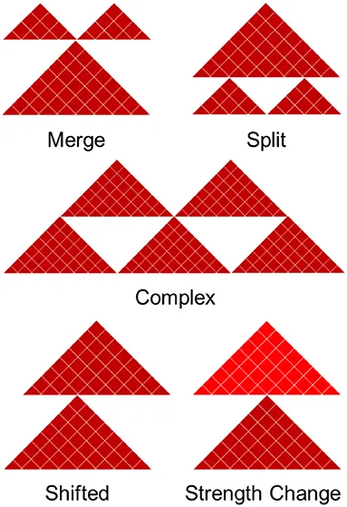

### 0.3.1 Boundary Changes Categorization:

**Categories of Boundary Changes**: These 5 categories include: 1. Complex 2. Split 3. Merge 4. Shifted 5. Strength Change

1. **Split**:
   - An interacting domain can exist as a continuous domain in one dataset and split into two or more domains in another.
   - Requires two shared boundaries and a differential domain between them.
2. **Merge**:
   - Merging is the opposite of splitting.
   - Occurs when a boundary between two non-differential boundaries disappears in one of the contact matrices.
3. **Complex**:
   - Domains can also be modified in a complex way, meaning they neither split nor merge but instead adopt a completely new structure.
   - Complex boundaries are considered part of a different domain.

“Complex,” “merge,” and “split” boundaries represent the most disruptive changes in the 3D genome structure. - **Merged and Split Boundaries**: Represent structural changes within the same domain. - **Complex Boundaries**: Considered a part of an entirely different domain.

4. **Shifted**:
   - Defined as non-overlapping boundaries within five bins (or another user-defined threshold) of a boundary in the reference contact matrix.
5. **Strength Changes**:
   - Occur when a boundary is present in both contact matrices, but its differential boundary score magnitude exceeds a differential threshold of 2.

**Non-Differential Boundaries**: - Boundaries not fitting into the above categories are considered non-differential boundaries.

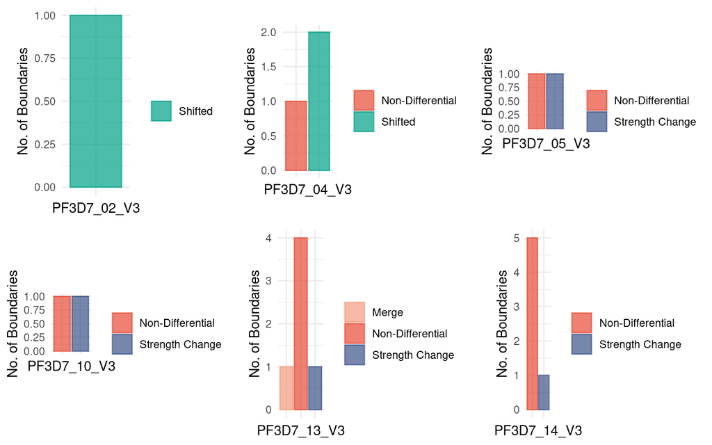

```r
#Performing differential TAD analysis for all chromosomes
p16hpi<-lapply(1:14, function(x){
  TADCompare(ko16[[x]], ctrl16[[x]], resolution=50000)})

plts<-lapply(1:14, function(x){
  df<-data.frame(table(p16hpi[[x]]$TAD_Frame$Type))
  ggplot(df,aes(Var1,Freq,col=Var1, fill=Var1))+geom_bar(stat = "identity",position="stack")+theme_minimal()+ scale_fill_manual(values=c("Non-Differential"="#E64B35B2","Complex"="#4DBBD5B2","Shifted"="#00A087B2","Strength Change"="#3C5488B2","Merge"="#F39B7FB2"))+
    scale_color_manual(values=c("Non-Differential"="#E64B35B2","Complex"="#4DBBD5B2","Shifted"="#00A087B2","Strength Change"="#3C5488B2","Merge"="#F39B7FB2"))+easy_remove_x_axis(what = c("ticks","text"))+coord_fixed(ratio = 3)+ylab("No. of Boundaries")+xlab(chrs[x])+easy_add_legend_title("")
  })
# library(ggstatsplot)
# plts1<-lapply(1:14, function(x){p16hpi[[x]]$Count_Plot})
# combine_plots(plotlist = plts)
# combine_plots(plotlist = plts[c(4,5,10,13,14)])
ggpubr::ggarrange(plts[2][[1]],plts[4][[1]],plts[5][[1]],plts[10][[1]],plts[13][[1]],plts[14][[1]])
```

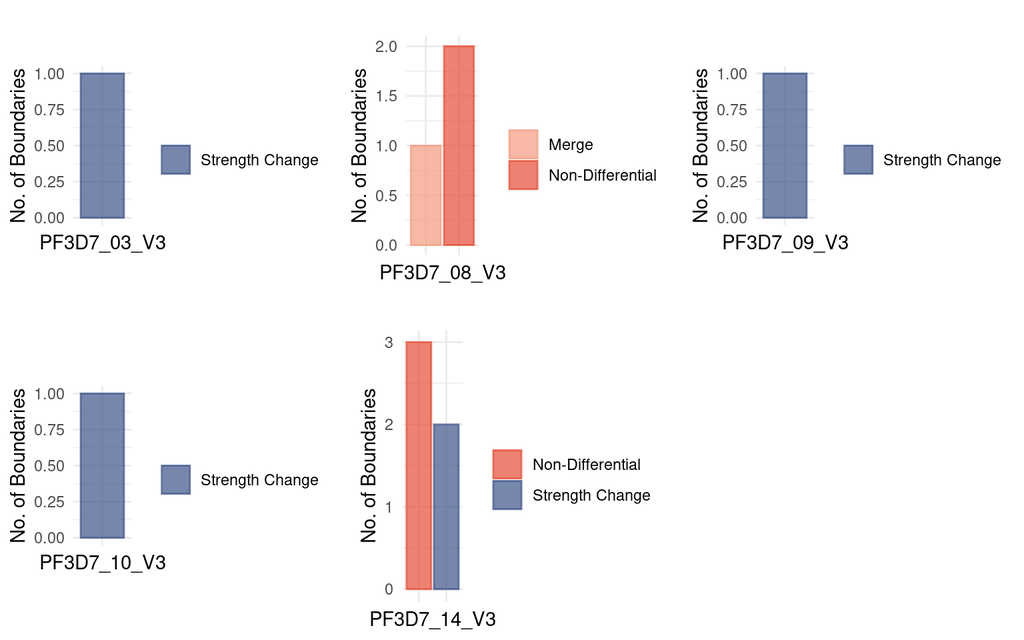

```r
## 40hpi
p40hpi<-lapply(1:14, function(x){
  TADCompare(ko40[[x]], ctrl40[[x]], resolution=50000)})


plts<-lapply(1:14, function(x){
  df<-data.frame(table(p40hpi[[x]]$TAD_Frame$Type))
  ggplot(df,aes(Var1,Freq,col=Var1, fill=Var1))+geom_bar(stat = "identity",position="stack")+theme_minimal()+ scale_fill_manual(values=c("Non-Differential"="#E64B35B2","Complex"="#4DBBD5B2","Shifted"="#00A087B2","Strength Change"="#3C5488B2","Merge"="#F39B7FB2"))+
    scale_color_manual(values=c("Non-Differential"="#E64B35B2","Complex"="#4DBBD5B2","Shifted"="#00A087B2","Strength Change"="#3C5488B2","Merge"="#F39B7FB2"))+easy_remove_x_axis(what = c("ticks","text"))+coord_fixed(ratio = 3)+ylab("No. of Boundaries")+xlab(chrs[x])+easy_add_legend_title("")
})
ggpubr::ggarrange(plts[3][[1]],plts[8][[1]],plts[9][[1]],plts[10][[1]],plts[14][[1]])
```